# CEU Machine Learning Concepts - Lab 1

János K. Divényi

```r
library(tidyverse)
library(skimr)

options(scipen = 99)  # avoid scientific notation
options(max.print = 20)  # avoid long outputs
options(str = strOptions(list.len = 20))  # avoid long outputs
theme_set(theme_minimal())
```

## Our problem

Let’s start with a simple linear model:

$$Y = X'\beta + \varepsilon = \beta_1 X_1^2 + \beta_2 X_1 +
\varepsilon$$
We have 2 variables available $X = (X_1, X_2)$ but only one of them is related to the outcome.

The true model is:

$$Y = X_1^2 - 1.5 X_1+ \varepsilon$$

## Estimation

```r
f_y_x <- function(x1) {
    x1^2 - 1.5 * x1
}
```

```r
n <- 100
set.seed(20230206)

data <- tibble(
    x1 = runif(n),
    x2 = runif(n),
    y = f_y_x(x1) + rnorm(n)
)
skim(data)
```

Data summary

| Name | data |
| --- | --- |
| Number of rows | 100 |
| Number of columns | 3 |
| _______________________ |  |
| Column type frequency: |  |
| numeric | 3 |
| ________________________ |  |
| Group variables | None |

**Variable type: numeric**

| skim_variable | n_missing | complete_rate | mean | sd | p0 | p25 | p50 | p75 | p100 | hist |
| --- | --- | --- | --- | --- | --- | --- | --- | --- | --- | --- |
| x1 | 0 | 1 | 0.48 | 0.30 | 0.01 | 0.21 | 0.51 | 0.76 | 1.00 | ▇▆▅▆▆ |
| x2 | 0 | 1 | 0.51 | 0.28 | 0.01 | 0.28 | 0.50 | 0.75 | 0.99 | ▅▇▇▆▇ |
| y | 0 | 1 | -0.49 | 0.94 | -2.87 | -1.07 | -0.46 | 0.04 | 2.35 | ▂▃▇▃▁ |

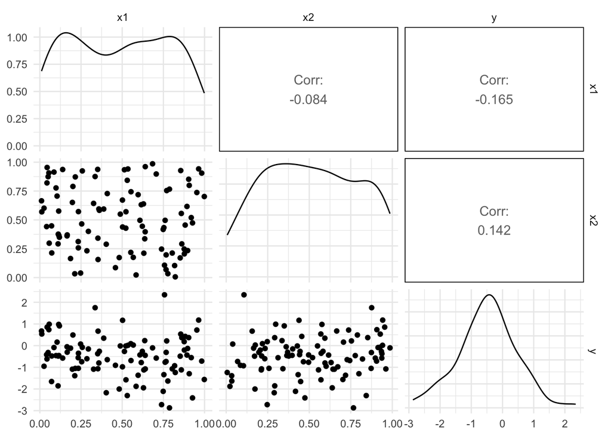

```r
GGally::ggpairs(data)
```

```r
f_hat_x <- lm(y ~ x1 + I(x1^2), data)
f_hat_x
```

```
##
## Call:
## lm(formula = y ~ x1 + I(x1^2), data = data)
##
## Coefficients:
## (Intercept)           x1      I(x1^2)
##      0.0824      -2.6707       2.2291
```

```r
point_to_evaluate <- list(x1 = 0, x2 = 0)
list(
    true_value = f_y_x(point_to_evaluate$x1),
    predicted_value = as.numeric(predict(f_hat_x, newdata = point_to_evaluate))
)
```

```
## $true_value
## [1] 0
##
## $predicted_value
## [1] 0.08239
```

```r
f_hat_simple_x <- lm(y ~ x1, data)
f_hat_simple_x
```

```
##
## Call:
## lm(formula = y ~ x1, data = data)
##
## Coefficients:
## (Intercept)           x1
##      -0.238       -0.514
```

```r
list(
    true_value = f_y_x(point_to_evaluate$x1),
    predicted_value = as.numeric(predict(f_hat_x, newdata = point_to_evaluate)),
    predicted_value_simple = as.numeric(predict(f_hat_simple_x, newdata = point_to_evaluate))
)
```

```
## $true_value
## [1] 0
##
## $predicted_value
## [1] 0.08239
##
## $predicted_value_simple
## [1] -0.2377
```

## The magical `map`

The map functions in the `purrr` package (part of `tidyverse`) *“transform their input by applying a function to each element of a list or atomic vector and returning an object of the same length as the input”*. ([Source](https://purrr.tidyverse.org/reference/map.html))

```r
mean(rnorm(1000))
```

```
## [1] 0.03264
```

```r
map(c(5, 10, 20), rnorm)
```

```
## [[1]]
## [1] -0.3403  1.6038  1.3316  2.0938 -0.5799
##
## [[2]]
##  [1]  2.32646  0.06776  0.31704  0.05522  1.40895  0.27878  0.39784  0.73382  0.58361 -0.77415
##
## [[3]]
##  [1]  1.09999  0.85452  0.19154 -1.51653 -0.78368  0.07127  1.14791 -1.08498  1.38175  0.12788 -0.40327 -1.07134  0.14398 -0.24095 -0.95386 -0.42505 -1.64509  0.12506  1.80132  0.33362
```

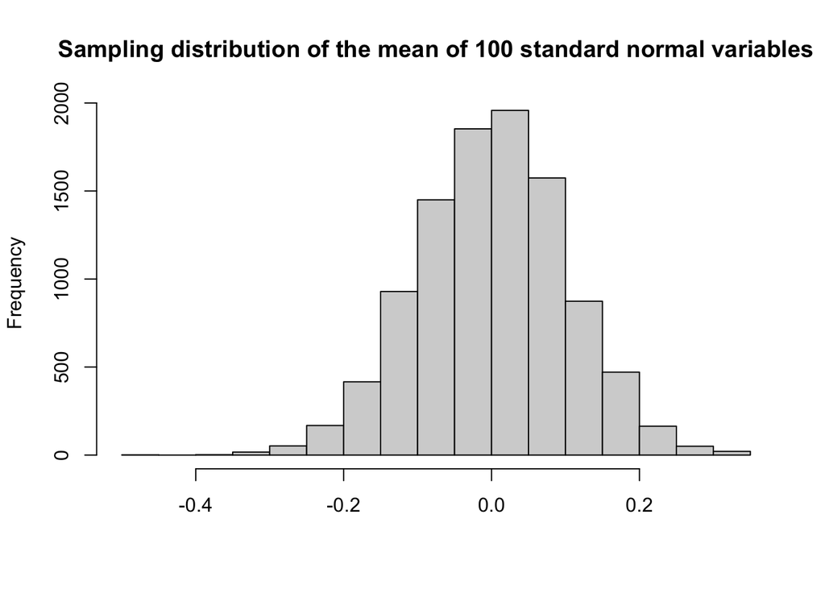

```r
n <- 100
n_sim <- 10000
map_dbl(
    seq(n_sim),
    ~mean(rnorm(n))
) |>
    hist(
        main = glue::glue("Sampling distribution of the mean of {n} standard normal variables"),
        xlab = ""
    )
```

```r
sds <- c(1, 5)
map(sds, function(s) {
    map_dbl(
        seq(n_sim),
        ~mean(rnorm(n, sd = s))
    )
})
```

```
## [[1]]
##  [1] -0.165779 -0.131159 -0.083698  0.010624  0.059586 -0.082538  0.045920 -0.021180 -0.029209 -0.114798  0.067808  0.046779 -0.021603  0.060839  0.140305 -0.007727 -0.027006 -0.094539  0.002484
## [20] -0.061033
##  [ reached getOption("max.print") -- omitted 9980 entries ]
##
## [[2]]
##  [1]  0.14264  0.28834  0.55955  0.81213 -0.06988  0.40011  0.60698  0.64421  0.32670 -0.39284 -0.23683 -1.11713 -0.85915  0.18569 -0.43982 -0.74690 -0.16762  0.46722  0.84544  0.12797
##  [ reached getOption("max.print") -- omitted 9980 entries ]
```

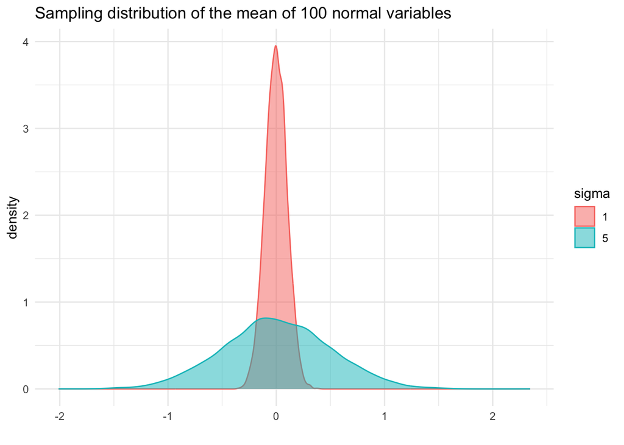

```r
map_df(sds, function(s) {
    tibble(
        sigma = as.factor(s),
        sample_avg = map_dbl(
            seq(n_sim),
            ~mean(rnorm(n, sd = s))
        )
    )
}) |> ggplot(aes(sample_avg, fill = sigma, color = sigma)) +
    geom_density(alpha = 0.5) +
    labs(
        title = glue::glue("Sampling distribution of the mean of {n} normal variables"),
        x = ""
    )
```

## Simulation

```r
runSimulationStep <- function(n = 100, sd_e = 1) {
    # Step 1: Simulate the data
    data <- tibble(
        x1 = runif(n),
        x2 = runif(n),
        y = f_y_x(x1) + rnorm(n, sd = sd_e)
    )

    # Step 2: Estimation
    list(
        true = lm(y ~ x1 + I(x1^2), data),
        simple = lm(y ~ x1, data),
        full = lm(y ~ polym(x1, x2, degree = 2, raw = TRUE), data)
    )
}
```

```r
estimated_models <- runSimulationStep()
estimated_models
```

```
## $true
##
## Call:
## lm(formula = y ~ x1 + I(x1^2), data = data)
##
## Coefficients:
## (Intercept)           x1      I(x1^2)
##     -0.0134      -0.9565       0.4958
##
##
## $simple
##
## Call:
## lm(formula = y ~ x1, data = data)
##
## Coefficients:
## (Intercept)           x1
##      -0.093       -0.454
##
##
## $full
##
## Call:
## lm(formula = y ~ polym(x1, x2, degree = 2, raw = TRUE), data = data)
##
## Coefficients:
##                              (Intercept)  polym(x1, x2, degree = 2, raw = TRUE)1.0  polym(x1, x2, degree = 2, raw = TRUE)2.0  polym(x1, x2, degree = 2, raw = TRUE)0.1
##                                    0.252                                    -1.557                                     0.565                                    -0.380
## polym(x1, x2, degree = 2, raw = TRUE)1.1  polym(x1, x2, degree = 2, raw = TRUE)0.2
##                                    1.090                                    -0.179
```

```r
point_to_evaluate <- list(x1 = 0, x2 = 0)
map(estimated_models, ~as.numeric(predict(.x, newdata = point_to_evaluate)))
```

```
## $true
## [1] -0.01343
##
## $simple
## [1] -0.09303
##
## $full
## [1] 0.2523
```

```r
set.seed(20230206)

n_sim <- 1000
simulated_models <- map(seq(n_sim), ~runSimulationStep())
```

```r
str(simulated_models, max.level = 1)
```

```
## List of 1000
##  $ :List of 3
##  $ :List of 3
##  $ :List of 3
##  $ :List of 3
##  $ :List of 3
##  $ :List of 3
##  $ :List of 3
##  $ :List of 3
##  $ :List of 3
##  $ :List of 3
##  $ :List of 3
##  $ :List of 3
##  $ :List of 3
##  $ :List of 3
##  $ :List of 3
##  $ :List of 3
##  $ :List of 3
##  $ :List of 3
##  $ :List of 3
##  $ :List of 3
##   [list output truncated]
```

```r
simulated_models[[1]]
```

```
## $true
##
## Call:
## lm(formula = y ~ x1 + I(x1^2), data = data)
##
## Coefficients:
## (Intercept)           x1      I(x1^2)
##      0.0824      -2.6707       2.2291
##
##
## $simple
##
## Call:
## lm(formula = y ~ x1, data = data)
##
## Coefficients:
## (Intercept)           x1
##      -0.238       -0.514
##
##
## $full
##
## Call:
## lm(formula = y ~ polym(x1, x2, degree = 2, raw = TRUE), data = data)
##
## Coefficients:
##                              (Intercept)  polym(x1, x2, degree = 2, raw = TRUE)1.0  polym(x1, x2, degree = 2, raw = TRUE)2.0  polym(x1, x2, degree = 2, raw = TRUE)0.1
##                                  -0.0167                                   -2.3338                                    2.0601                                   -0.5666
## polym(x1, x2, degree = 2, raw = TRUE)1.1  polym(x1, x2, degree = 2, raw = TRUE)0.2
##                                  -0.3141                                    1.0457
```

```r
predictions00 <- map_df(simulated_models, ~{
    map(.x, ~as.numeric(predict(.x, newdata = point_to_evaluate))) |> as_tibble()
})
```

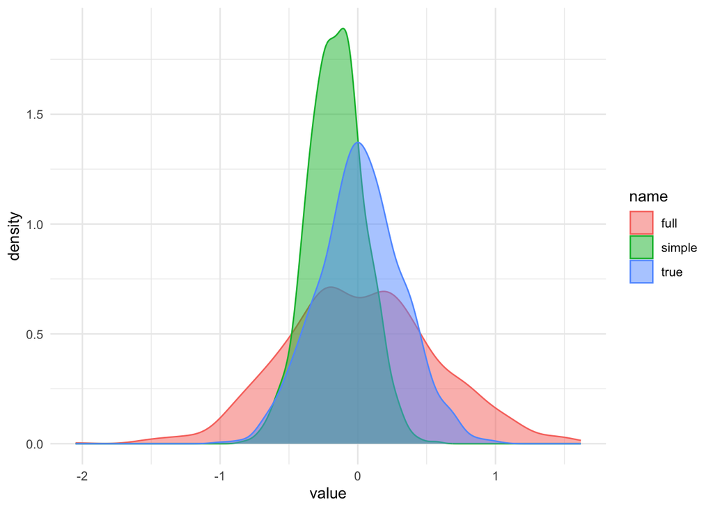

```r
pivot_longer(predictions00, cols = everything()) |>
    ggplot(aes(value, color = name, fill = name)) + geom_density(alpha = 0.5)
```

```r
pivot_longer(predictions00, cols = everything()) |>
    group_by(name) |>
    summarise(
        bias = mean(value) - f_y_x(point_to_evaluate$x1),
        var = var(value),
        MSE = mean((value - f_y_x(point_to_evaluate$x1))^2)
    )
```

| name | bias | var | MSE |
| --- | --- | --- | --- |
| full | 0.01650 | 0.29297 | 0.29295 |
| simple | -0.15648 | 0.04133 | 0.06578 |
| true | 0.01702 | 0.09264 | 0.09283 |

Note that on average the simpler model gave better predictions than the true model. Tip: simulate with `n=500` or `sd_e = 0.1` and compare those results with these. Can you explain the difference?

## Get some intuition for bias-variance trade-off

To get some intuition as to why the simpler (wrong) model performed better, let’s take a look at the predictions for different values of $X_1$. Here we take advantage of the fact that the `predict()` function also works with multiple values of the features.

```r
points_to_evaluate <- tibble(x1 = seq(0, 1, 0.05), x2 = 0)
predict(f_hat_x, newdata = points_to_evaluate)
```

```
##        1        2        3        4        5        6        7        8        9       10       11       12       13       14       15       16       17       18       19       20       21
##  0.08239 -0.04557 -0.16239 -0.26806 -0.36259 -0.44597 -0.51820 -0.57929 -0.62924 -0.66803 -0.69569 -0.71220 -0.71756 -0.71177 -0.69485 -0.66677 -0.62755 -0.57719 -0.51568 -0.44302 -0.35922
```

```r
predictions <- map_df(seq_along(simulated_models[1:50]), function(i) {
    map(simulated_models[[i]], ~predict(.x, newdata = points_to_evaluate)) |>
        bind_cols() |>
        mutate(simulation_run = i, x1 = points_to_evaluate$x1)
})
```

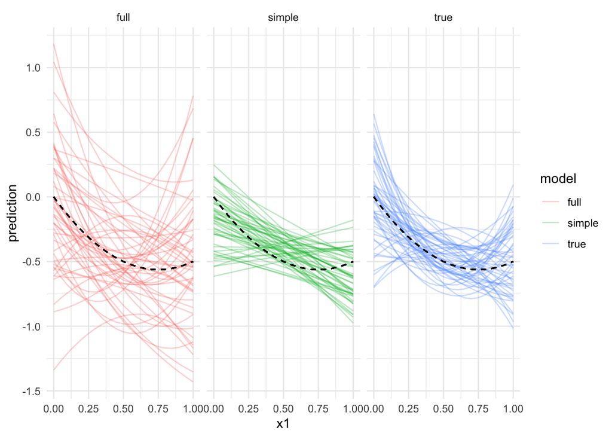

```r
predictions |>
    mutate(true_value = f_y_x(x1)) |>
    pivot_longer(cols = true:full, names_to = "model", values_to = "prediction") |>
    ggplot(aes(x1, prediction, group = simulation_run, col = model)) +
        geom_line(alpha = 0.3) +
        geom_line(aes(y = true_value), color = "black", linetype = "dashed") +
        facet_wrap(~ model)
```

The true relationship is indicated by the dashed line. It is clear that the simple model has no chance of revealing the true relationship, but it is still closer to it on average, since the true model (not to mention the full model) is highly variable.

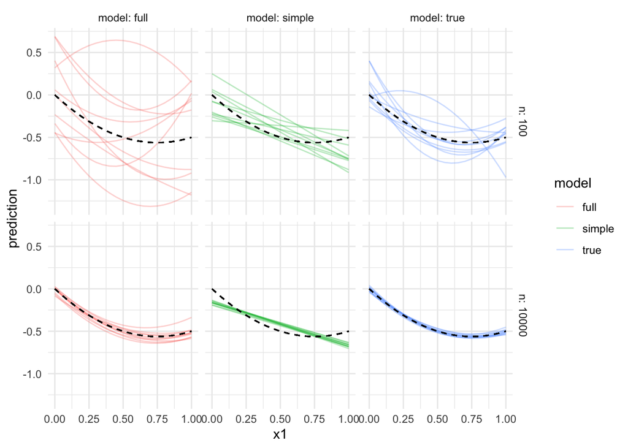

```r
nobs <- c(100, 10000)
map_df(nobs, function(n) {
    simulated_models <- map(seq(10), ~runSimulationStep(n = n))
    map_df(seq_along(simulated_models), function(i) {
        map(simulated_models[[i]], ~predict(.x, newdata = points_to_evaluate)) |>
            bind_cols() |>
            mutate(n = n, simulation_run = i, x1 = points_to_evaluate$x1)
    })
}) |>
    mutate(true_value = f_y_x(x1)) |>
    pivot_longer(cols = true:full, names_to = "model", values_to = "prediction") |>
    ggplot(aes(x1, prediction, group = simulation_run, col = model)) +
        geom_line(alpha = 0.3) +
        geom_line(aes(y = true_value), color = "black", linetype = "dashed") +
        facet_grid(n ~ model, labeller = label_both)
```

You can play along with this [Shiny App](https://divenyijanos.shinyapps.io/bias-variance-app/) which I put together to illustrate the bias-variance trade-off.